# RiscaldamentoGlobale slides

### Andrea Plai

Matricola 167223

## Fondamenti Di Scienza Dei Dati E Laboratorio

**Titolo:** Riscaldamento globale: Evoluzione della temperatura terrestre

Premi in qualsiasi momento per vedere la mappa di navigazione

## 2. Descrizione dei dati

Dati di 3448 città ottenuti dal 1743 al 2013 con le seguenti informazioni:

- Temperatura media
- Latiudine e longitudine
- Paese di appartenenza

**Fonte:** **Kaggle** - [Berkeley Earth Surface Temperature Data](https://www.kaggle.com/datasets/berkeleyearth/climate-change-earth-surface-temperature-data)

## Dataset Città

Contine le seguenti informazioni per 248 stati

- Numero totale di abitanti per città.
- Latitudine e longitudine esatte.
- Nome della città appartente ad uno stato.

**Fonte:** **SimpleMaps** - [World Cities Database](https://simplemaps.com/data/world-cities)

### Campione parziale del dataset 📊

Il dataset finale è stato ottenuto unendo i due dataset citati precedentemente. Il motivo di questa operazione è dovuto dalla poca prescisione dei dataset già esistenti

Attenzione: colonne omesse per chiarezza esemplificativa.

|  | City | Country | Year | AverageTemperature | population |
| --- | --- | --- | --- | --- | --- |
| 859130 | Velikie Luki | Russia | 1936 | 5.673333 | 85989.0 |
| 303177 | Handan | China | 1959 | 14.122500 | 2708015.0 |
| 50554 | Austin | United States | 1832 | 19.553417 | 26167.0 |
| 703435 | San Luis | Argentina | 1904 | 17.261333 | 35998.0 |
| 266054 | Gent | Belgium | 1844 | 9.035667 | 265086.0 |

## 3. Research questions

### Lo studio mira a rispondere alle seguenti domande:

- Q1: Come è cambiata la temperatura media annuale nelle diverse fasce di latitudine?
- l'Emisfero Nord e l'Emisfero Sud si stanno riscaldando allo stesso ritmo?
- La stagionalità è cambiata nel tempo?
- Q2: Le città influenzano l'aumento di temperatura?
- Quali città soffrono di piu questo fenomeno?
- Quale continente si sta scaldando più rapidamnete?

## 3.1 Fasce Latitudinali

Le fasce *polare* e *temperata* stanno aumentando di circa 1°C per secolo **(1.08 e 0.98 rispettivamente)**, mentre i *tropici* si scaldano più lentamente, a circa **0.76°C per secolo**.

[interactive chart not shown]

## 3.1 Confronto tra emisferi

L'emisfero Nord mostra un'anomalia di *+2.60 °C/secolo*, contro *+1.61 °C/secolo* dell'emisfero Sud.

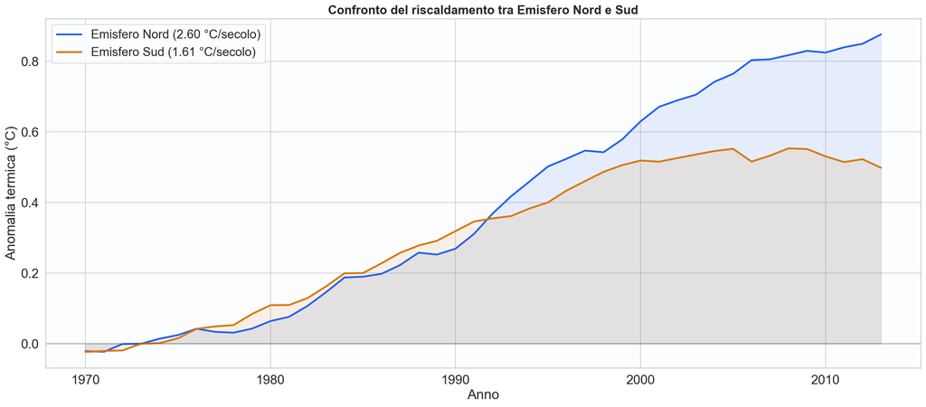

## 3.1 Stagionalità

Le *anomalie* crescono soprattutto nei mesi freddi.

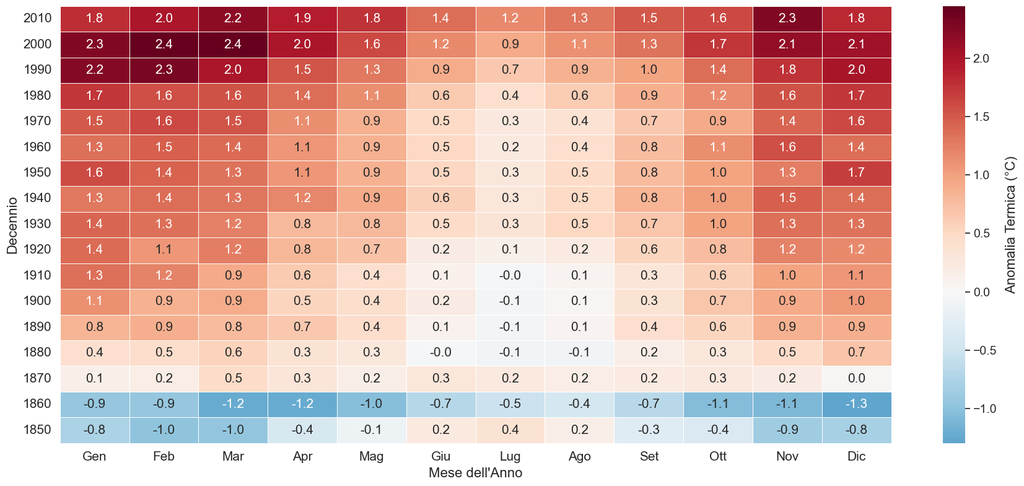

## 3.2 Urbanizzazione

Le mediane del trend mostrano che le città di *piccole dimensioni* si collocano a *0.67°C* per secolo, le *medie città* a *0.73°C*, le *grandi città* a *0.80°C* e le *megalopoli* a *0.78°C*.

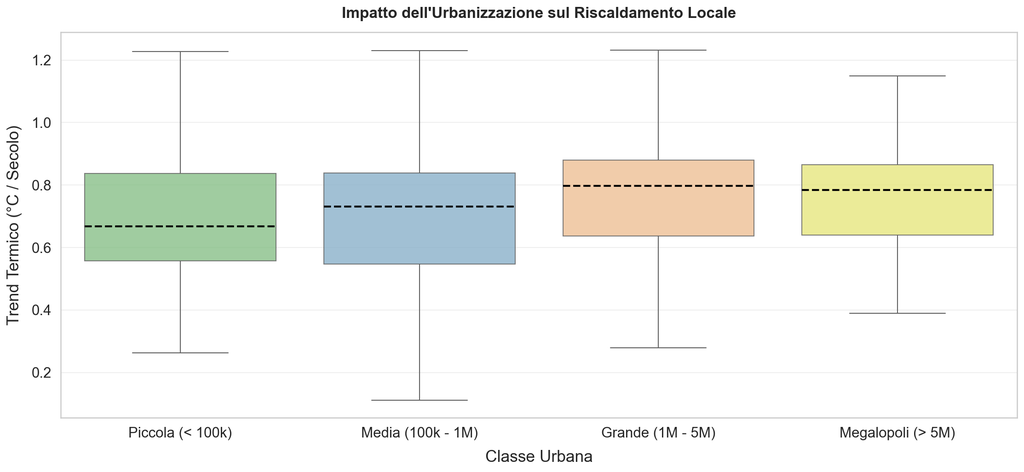

## 3.2 Classifica Città

Le città con la maggiore variazione di temperatura sono tre : *Engels, Atyrau, Aqtobe* con un aumento di *2.33°C*

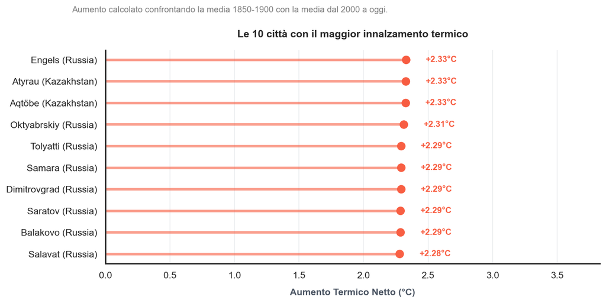

## 3.2 Divario Continentale

*L'Europa* è il continente che si sta scaldando più velocemente

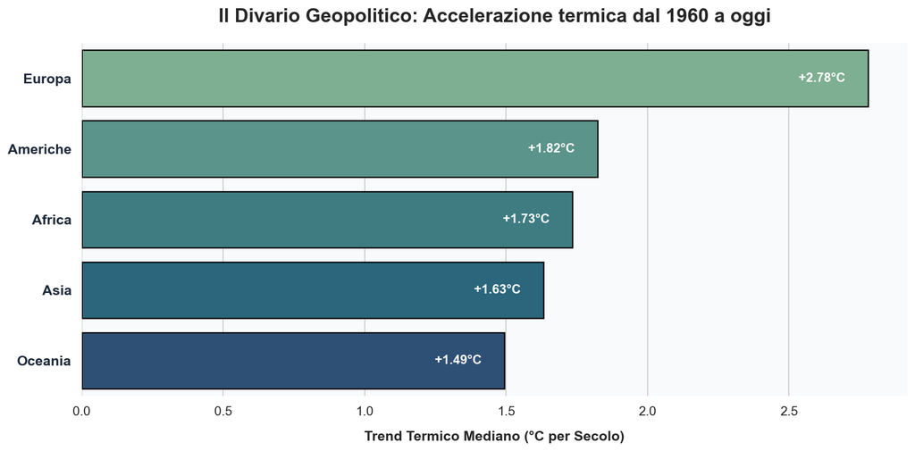

## Q1: Latitudini, Emisferi e Stagionalità

- **Fasce climatiche:** Riscaldamento maggiore ai Poli (+1.08 °C/secolo) e nelle zone temperate (+0.98) rispetto ai Tropici (+0.76).
- **Emisferi:** Il Nord (+2.60 °C/secolo) si scalda a ritmi superiori rispetto al Sud (+1.60).
- **Stagionalità:** Le anomalie termiche colpiscono con più forza i **mesi freddi**, riducendo la portata dei periodi storicamente rigidi.

## Q2: Urbanizzazione e Divario Geografico

- **Effetto città:** L'urbanizzazione amplifica il calore. Il trend cresce progressivamente con l'estensione urbana (da +0.67 °C/secolo per le piccole fino a +0.80 per le grandi).
- **Città più colpite:** **Engels, Atyrau, Aqtobe** guidano la classifica globale con un picco di +2.33 °C rispetto alle medie storiche.
- **Divario continentale:** L'**Europa** risulta il continente con l'accelerazione termica più rapida in assoluto.